# Assignment_4

```r
library(gapminder)
library(tidyverse)
```

# 1 Univariate Option 1

## 1.1 Make a tibble with one row per year, and columns for life expectancy for two or more countries.

```r
gapminder %>%
  select(year, lifeExp, country) %>%
  filter(country == "Cambodia" | country == "Vietnam" | country == "Thailand") %>%
  pivot_wider(names_from = country,
              values_from = lifeExp) %>%
  DT::datatable()
```

|  | year | Cambodia | Thailand | Vietnam |
| --- | --- | --- | --- | --- |
| 1 | 1952 | 39.417 | 50.848 | 40.412 |
| 2 | 1957 | 41.366 | 53.63 | 42.887 |
| 3 | 1962 | 43.415 | 56.061 | 45.363 |
| 4 | 1967 | 45.415 | 58.285 | 47.838 |
| 5 | 1972 | 40.317 | 60.405 | 50.254 |
| 6 | 1977 | 31.22 | 62.494 | 55.764 |
| 7 | 1982 | 50.957 | 64.597 | 58.816 |
| 8 | 1987 | 53.914 | 66.084 | 62.82 |
| 9 | 1992 | 55.803 | 67.298 | 67.662 |
| 10 | 1997 | 56.534 | 67.521 | 70.672 |

[output cut: 2 more lines]

## 1.2 Take advantage of this new data shape to scatterplot life expectancy for one country against that of another.

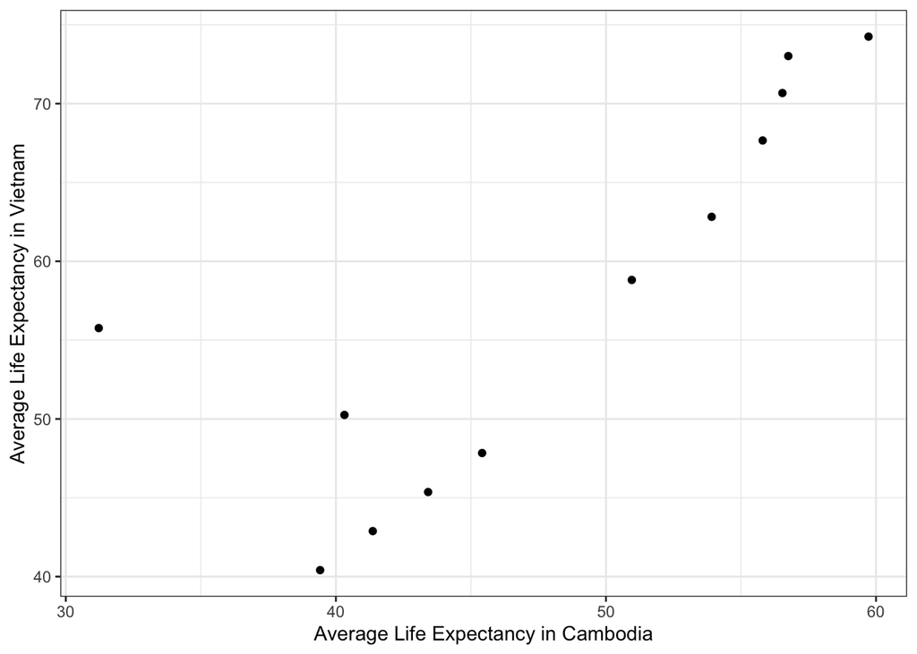

```r
gapminder %>%
  select(year, lifeExp, country) %>%
  filter(country == "Cambodia" | country == "Vietnam" | country == "Thailand") %>%
  pivot_wider(names_from = country,
              values_from = lifeExp) %>%
  ggplot(aes(x = Cambodia, y = Vietnam)) +
    geom_point() +
    xlab(label = "Average Life Expectancy in Cambodia") +
    ylab(label = "Average Life Expectancy in Vietnam") +
    theme_bw()
```

The two are directly proportional except for two outlier years during which Cambodia had a much lower life expectancy than did Vietnam.

## 1.3 Re-lengthen the data.

```r
gapminder %>%
  select(year, lifeExp, country) %>%
  filter(country == "Cambodia" | country == "Vietnam" | country == "Thailand") %>%
  pivot_wider(names_from = country,
              values_from = lifeExp) %>%
  pivot_longer(cols = c(Cambodia, Vietnam, Thailand),
               names_to = "country",
               values_to = "lifeExp") %>%
  DT::datatable()
```

|  | year | country | lifeExp |
| --- | --- | --- | --- |
| 1 | 1952 | Cambodia | 39.417 |
| 2 | 1952 | Vietnam | 40.412 |
| 3 | 1952 | Thailand | 50.848 |
| 4 | 1957 | Cambodia | 41.366 |
| 5 | 1957 | Vietnam | 42.887 |
| 6 | 1957 | Thailand | 53.63 |
| 7 | 1962 | Cambodia | 43.415 |
| 8 | 1962 | Vietnam | 45.363 |
| 9 | 1962 | Thailand | 56.061 |
| 10 | 1967 | Cambodia | 45.415 |

[output cut: 26 more lines]

The table is returned to its original length.

# 2 Multivariate Option 1

## 2.1 Make a tibble with one row per year, and columns for life expectancy and GDP per capita (or two other numeric variables) for two or more countries.

```r
gapminder %>%
  select(year, country, lifeExp, gdpPercap) %>%
  filter(country == "Brazil" | country == "Colombia") %>%
  pivot_wider(names_from = c(country),
              names_sep = "_",
              values_from = c(lifeExp, gdpPercap)) %>%
  DT::datatable()
```

|  | year | lifeExp_Brazil | lifeExp_Colombia | gdpPercap_Brazil | gdpPercap_Colombia |
| --- | --- | --- | --- | --- | --- |
| 1 | 1952 | 50.917 | 50.643 | 2108.944355 | 2144.115096 |
| 2 | 1957 | 53.285 | 55.118 | 2487.365989 | 2323.805581 |
| 3 | 1962 | 55.665 | 57.863 | 3336.585802 | 2492.351109 |
| 4 | 1967 | 57.632 | 59.963 | 3429.864357 | 2678.729839 |
| 5 | 1972 | 59.504 | 61.623 | 4985.711467 | 3264.660041 |
| 6 | 1977 | 61.489 | 63.837 | 6660.118654 | 3815.80787 |
| 7 | 1982 | 63.336 | 66.653 | 7030.835878 | 4397.575659 |
| 8 | 1987 | 65.205 | 67.768 | 7807.095818 | 4903.2191 |
| 9 | 1992 | 67.057 | 68.421 | 6950.283021 | 5444.648617 |
| 10 | 1997 | 69.388 | 70.313 | 7957.980824 | 6117.361746 |

[output cut: 2 more lines]

## 2.2 Re-lengthen the data.

```r
gapminder %>%
  select(year, country, lifeExp, gdpPercap) %>%
  filter(country == "Brazil" | country == "Colombia") %>%
  pivot_wider(names_from = c(country),
              names_sep = "_",
              values_from = c(lifeExp, gdpPercap)) %>%
  pivot_longer(cols = -year,
               names_to = c(".value", "country"),
               names_sep = "_") %>%
  DT::datatable()
```

|  | year | country | lifeExp | gdpPercap |
| --- | --- | --- | --- | --- |
| 1 | 1952 | Brazil | 50.917 | 2108.944355 |
| 2 | 1952 | Colombia | 50.643 | 2144.115096 |
| 3 | 1957 | Brazil | 53.285 | 2487.365989 |
| 4 | 1957 | Colombia | 55.118 | 2323.805581 |
| 5 | 1962 | Brazil | 55.665 | 3336.585802 |
| 6 | 1962 | Colombia | 57.863 | 2492.351109 |
| 7 | 1967 | Brazil | 57.632 | 3429.864357 |
| 8 | 1967 | Colombia | 59.963 | 2678.729839 |
| 9 | 1972 | Brazil | 59.504 | 4985.711467 |
| 10 | 1972 | Colombia | 61.623 | 3264.660041 |

[output cut: 14 more lines]

The table is returned to it’s original length.

# 3 Table Joins

```r
guest <- read_csv("https://raw.githubusercontent.com/STAT545-UBC/Classroom/master/data/wedding/attend.csv")
email <- read_csv("https://raw.githubusercontent.com/STAT545-UBC/Classroom/master/data/wedding/emails.csv")
```

## 3.1 For each guest in the guestlist (guest tibble), add a column for email address, which can be found in the email tibble.

```r
email %>%
  separate_rows(guest, sep = ", ") %>%
  rename(name = guest) %>%
  right_join(guest, by = "name") %>%
  DT::datatable()
```

|  | name | email | party | meal_wedding | meal_brunch | attendance_wedding | attendance_brunch | attendance_golf |
| --- | --- | --- | --- | --- | --- | --- | --- | --- |
| 1 | Sommer Medrano | sommm@gmail.com | 1 | PENDING | PENDING | PENDING | PENDING | PENDING |
| 2 | Phillip Medrano | sommm@gmail.com | 1 | vegetarian | Menu C | CONFIRMED | CONFIRMED | CONFIRMED |
| 3 | Blanka Medrano | sommm@gmail.com | 1 | chicken | Menu A | CONFIRMED | CONFIRMED | CONFIRMED |
| 4 | Emaan Medrano | sommm@gmail.com | 1 | PENDING | PENDING | PENDING | PENDING | PENDING |
| 5 | Blair Park | bpark@gmail.com | 2 | chicken | Menu C | CONFIRMED | CONFIRMED | CONFIRMED |
| 6 | Nigel Webb | bpark@gmail.com | 2 |  |  | CANCELLED | CANCELLED | CANCELLED |
| 7 | Sinead English | singlish@hotmail.ca | 3 | PENDING | PENDING | PENDING | PENDING | PENDING |
| 8 | Ayra Marks | marksa42@gmail.com | 4 | vegetarian | Menu B | PENDING | PENDING | PENDING |
| 9 | Atlanta Connolly |  | 5 | PENDING | PENDING | PENDING | PENDING | PENDING |
| 10 | Denzel Connolly |  | 5 | fish | Menu B | CONFIRMED | CONFIRMED | CONFIRMED |

[output cut: 20 more lines]

## 3.2 Who do we have emails for, yet are not on the guestlist?

```r
email %>%
  separate_rows(guest, sep = ", ") %>%
  rename(name = guest) %>%
  anti_join(guest) %>%
  knitr::kable()
```

| name | email |
| --- | --- |
| Turner Jones | tjjones12@hotmail.ca |
| Albert Marshall | themarshallfamily1234@gmail.com |
| Vivian Marshall | themarshallfamily1234@gmail.com |

We have emails for Turner Jones, Albert Marshall, and Vivian Marshall, but they are not on the guest list.

## 3.3 Make a guestlist that includes everyone we have emails for (in addition to those on the original guestlist).

```r
email %>%
  separate_rows(guest, sep = ", ") %>%
  rename(name = guest) %>%
  full_join(guest, by = "name") %>%
  DT::datatable()
```

|  | name | email | party | meal_wedding | meal_brunch | attendance_wedding | attendance_brunch | attendance_golf |
| --- | --- | --- | --- | --- | --- | --- | --- | --- |
| 1 | Sommer Medrano | sommm@gmail.com | 1 | PENDING | PENDING | PENDING | PENDING | PENDING |
| 2 | Phillip Medrano | sommm@gmail.com | 1 | vegetarian | Menu C | CONFIRMED | CONFIRMED | CONFIRMED |
| 3 | Blanka Medrano | sommm@gmail.com | 1 | chicken | Menu A | CONFIRMED | CONFIRMED | CONFIRMED |
| 4 | Emaan Medrano | sommm@gmail.com | 1 | PENDING | PENDING | PENDING | PENDING | PENDING |
| 5 | Blair Park | bpark@gmail.com | 2 | chicken | Menu C | CONFIRMED | CONFIRMED | CONFIRMED |
| 6 | Nigel Webb | bpark@gmail.com | 2 |  |  | CANCELLED | CANCELLED | CANCELLED |
| 7 | Sinead English | singlish@hotmail.ca | 3 | PENDING | PENDING | PENDING | PENDING | PENDING |
| 8 | Ayra Marks | marksa42@gmail.com | 4 | vegetarian | Menu B | PENDING | PENDING | PENDING |
| 9 | Jolene Welsh | jw1987@hotmail.com | 6 |  |  | CANCELLED | CANCELLED | CANCELLED |
| 10 | Hayley Booker | jw1987@hotmail.com | 6 | vegetarian | Menu C | CONFIRMED | CONFIRMED | CONFIRMED |

[output cut: 23 more lines]

This table includes everyone we have emails for as well as everyone on the original guestlist.